# Project: Predict Bike Sharing Demand with AutoGluon

## Understand Data

### Data Fields

- datetime - hourly date + timestamp
- season - 1 = spring, 2 = summer, 3 = fall, 4 = winter
- holiday - whether the day is considered a holiday
- workingday - whether the day is neither a weekend nor holiday
- weather - 1: Clear, Few clouds, Partly cloudy, Partly cloudy, 2: Mist + Cloudy, Mist + Broken clouds, Mist + Few clouds, Mist, 3: Light Snow, Light Rain + Thunderstorm + Scattered clouds, Light Rain + Scattered clouds, 4: Heavy Rain + Ice Pallets + Thunderstorm + Mist, Snow + Fog
- temp - temperature in Celsius
- atemp - "feels like" temperature in Celsius
- humidity - relative humidity
- windspeed - wind speed
- casual - number of non-registered user rentals initiated
- registered - number of registered user rentals initiated
- count - number of total rental

## Download the Kaggle dataset using the kaggle python library

**Setting Kaggle API Key & API token file are complete**

### Setup Kaggle API Key

```python
# create the .kaggle directory and an empty kaggle.json file

!touch /Users/murali/kaggle.json
!chmod 600 /Users/murali/kaggle.json
```

```python
# Fill in your user name and key from creating the kaggle account and API token file
import json

kaggle_username = "muralivarath"
kaggle_key = "534a5e8b527bd6ce702b472551952be2"

# Save API token the kaggle.json file
with open("/Users/murali/kaggle.json", "w") as f:
    f.write(json.dumps({"username": kaggle_username, "key": kaggle_key}))
```

### Download & Unzip Data

```python
# Download the dataset, it will be in a .zip file so you'll need to unzip it as well.
!kaggle competitions download -c bike-sharing-demand -p /Users/murali/workspace/balanzer/kaggle/data
```

```python
# Unzip data bike-sharing-demand.zip
```

### Loading necessary libraries for EDA

Load all standard python library packages.

#### Data Manipulation

- Numpy
- Pandas

#### Data Visualization

- matplotlib.pyplot
- seaborn

```python
import warnings

warnings.filterwarnings("ignore")


# this will help in making the Python code more structured automatically
%load_ext nb_black

import warnings

warnings.filterwarnings("ignore")

# Libraries to help with reading and manipulating data

import pandas as pd
import numpy as np

# Libraries to help with data visualization
import matplotlib.pyplot as plt
import seaborn as sns

# Removes the limit for the number of displayed columns
pd.set_option("display.max_columns", None)
# Sets the limit for the number of displayed rows
pd.set_option("display.max_rows", 200)


from sklearn.tree import DecisionTreeRegressor
from sklearn.ensemble import (
    BaggingRegressor,
    RandomForestRegressor,
    GradientBoostingRegressor,
    AdaBoostRegressor,
    StackingRegressor,
)
from xgboost import XGBRegressor
from sklearn import metrics
from sklearn.model_selection import GridSearchCV, train_test_split

from sklearn.model_selection import train_test_split
from autogluon.tabular import TabularPredictor
import autogluon.core as ag

# to check model performance
from sklearn.metrics import mean_absolute_error, mean_squared_error, r2_score


def genrerate_submit_data(model_to_predict, file_name="submission.csv"):
    print(f"genrating {file_name} for kaggle submission\n")
    submit_data = pd.DataFrame(test_orig["datetime"], columns=["datetime"])

    y_pred = model_to_predict.predict(data_test)

    # submit_data["count"] = y_pred
    submit_data["count"] = np.round(y_pred)
    # check sum of negative values
    print("Total negative values : \n")
    print(submit_data[submit_data["count"] < 0].count())

    # check how many negative values
    submit_data["count"] = submit_data["count"].apply(lambda x: x if x > 0 else 0)

    print("\nAfter replace negative values : \n")
    print(submit_data[submit_data["count"] < 0].count())

    submit_data.to_csv(file_name, index=False)
    display(submit_data.sample(10))
    print(f"\ncsv file {file_name} generated")
```

```python
# reading bike sharing train.csv data and load to data frame
train_orig = pd.read_csv("train.csv")
test_orig = pd.read_csv("test.csv")
# copying orignal data so that when changing data we dont lose original
data = train_orig.copy()
# copying orignal data so that when changing data we dont lose original
data_test = test_orig.copy()
```

### Understand the shape of the dataset.

```python
data.shape
```

```
(10886, 12)
```

### Check the data types of the columns in the dataset.

checking data types of all columns

```python
data.info()
```

```
<class 'pandas.core.frame.DataFrame'>
RangeIndex: 10886 entries, 0 to 10885
Data columns (total 12 columns):
 #   Column      Non-Null Count  Dtype
---  ------      --------------  -----
 0   datetime    10886 non-null  object
 1   season      10886 non-null  int64
 2   holiday     10886 non-null  int64
 3   workingday  10886 non-null  int64
 4   weather     10886 non-null  int64
 5   temp        10886 non-null  float64
 6   atemp       10886 non-null  float64
 7   humidity    10886 non-null  int64
 8   windspeed   10886 non-null  float64
 9   casual      10886 non-null  int64
 10  registered  10886 non-null  int64
 11  count       10886 non-null  int64
dtypes: float64(3), int64(8), object(1)
memory usage: 1020.7+ KB
```

### View the first and last 5 rows of the dataset.

```python
data.head(5)
```

|  | datetime | season | holiday | workingday | weather | temp | atemp | humidity | windspeed | casual | registered | count |
| --- | --- | --- | --- | --- | --- | --- | --- | --- | --- | --- | --- | --- |
| 0 | 2011-01-01 00:00:00 | 1 | 0 | 0 | 1 | 9.84 | 14.395 | 81 | 0.0 | 3 | 13 | 16 |
| 1 | 2011-01-01 01:00:00 | 1 | 0 | 0 | 1 | 9.02 | 13.635 | 80 | 0.0 | 8 | 32 | 40 |
| 2 | 2011-01-01 02:00:00 | 1 | 0 | 0 | 1 | 9.02 | 13.635 | 80 | 0.0 | 5 | 27 | 32 |
| 3 | 2011-01-01 03:00:00 | 1 | 0 | 0 | 1 | 9.84 | 14.395 | 75 | 0.0 | 3 | 10 | 13 |
| 4 | 2011-01-01 04:00:00 | 1 | 0 | 0 | 1 | 9.84 | 14.395 | 75 | 0.0 | 0 | 1 | 1 |

```python
data.tail(5)
```

|  | datetime | season | holiday | workingday | weather | temp | atemp | humidity | windspeed | casual | registered | count |
| --- | --- | --- | --- | --- | --- | --- | --- | --- | --- | --- | --- | --- |
| 10881 | 2012-12-19 19:00:00 | 4 | 0 | 1 | 1 | 15.58 | 19.695 | 50 | 26.0027 | 7 | 329 | 336 |
| 10882 | 2012-12-19 20:00:00 | 4 | 0 | 1 | 1 | 14.76 | 17.425 | 57 | 15.0013 | 10 | 231 | 241 |
| 10883 | 2012-12-19 21:00:00 | 4 | 0 | 1 | 1 | 13.94 | 15.910 | 61 | 15.0013 | 4 | 164 | 168 |
| 10884 | 2012-12-19 22:00:00 | 4 | 0 | 1 | 1 | 13.94 | 17.425 | 61 | 6.0032 | 12 | 117 | 129 |
| 10885 | 2012-12-19 23:00:00 | 4 | 0 | 1 | 1 | 13.12 | 16.665 | 66 | 8.9981 | 4 | 84 | 88 |

### Summary of the data

```python
data.describe().T
```

|  | count | mean | std | min | 25% | 50% | 75% | max |
| --- | --- | --- | --- | --- | --- | --- | --- | --- |
| season | 10886.0 | 2.506614 | 1.116174 | 1.00 | 2.0000 | 3.000 | 4.0000 | 4.0000 |
| holiday | 10886.0 | 0.028569 | 0.166599 | 0.00 | 0.0000 | 0.000 | 0.0000 | 1.0000 |
| workingday | 10886.0 | 0.680875 | 0.466159 | 0.00 | 0.0000 | 1.000 | 1.0000 | 1.0000 |
| weather | 10886.0 | 1.418427 | 0.633839 | 1.00 | 1.0000 | 1.000 | 2.0000 | 4.0000 |
| temp | 10886.0 | 20.230860 | 7.791590 | 0.82 | 13.9400 | 20.500 | 26.2400 | 41.0000 |
| atemp | 10886.0 | 23.655084 | 8.474601 | 0.76 | 16.6650 | 24.240 | 31.0600 | 45.4550 |
| humidity | 10886.0 | 61.886460 | 19.245033 | 0.00 | 47.0000 | 62.000 | 77.0000 | 100.0000 |
| windspeed | 10886.0 | 12.799395 | 8.164537 | 0.00 | 7.0015 | 12.998 | 16.9979 | 56.9969 |
| casual | 10886.0 | 36.021955 | 49.960477 | 0.00 | 4.0000 | 17.000 | 49.0000 | 367.0000 |
| registered | 10886.0 | 155.552177 | 151.039033 | 0.00 | 36.0000 | 118.000 | 222.0000 | 886.0000 |
| count | 10886.0 | 191.574132 | 181.144454 | 1.00 | 42.0000 | 145.000 | 284.0000 | 977.0000 |

```python
data.describe(include="object").T
```

|  | count | unique | top | freq |
| --- | --- | --- | --- | --- |
| datetime | 10886 | 10886 | 2011-07-03 00:00:00 | 1 |

### Check for Duplicates

lets check for any duplicate values

```python
# check for any duplicate data
data[data.duplicated()]
```

|  | datetime | season | holiday | workingday | weather | temp | atemp | humidity | windspeed | casual | registered | count |
| --- | --- | --- | --- | --- | --- | --- | --- | --- | --- | --- | --- | --- |

```python
#  Prints total null value count(s) for all columns in input data frame
def print_null_info(df):
    """
    Prints total null value count(s) & % for all columns in input data frame
    """

    nullInfo = {"missing count": df.isnull().sum(), "missing %": df.isnull().mean()}
    # Creates pandas DataFrame.
    nulldata = pd.DataFrame(nullInfo)
    return nulldata[nulldata["missing count"] > 0].sort_values(
        by="missing count", ascending=False
    )


print_null_info(data)
```

|  | missing count | missing % |
| --- | --- | --- |

```python
## Deleting columns not in test

data.drop("registered", inplace=True, axis=1)
data.drop("casual", inplace=True, axis=1)
```

```python
# Converting to data time

data["datetime"] = pd.to_datetime(data["datetime"])
data_test["datetime"] = pd.to_datetime(data_test["datetime"])
data.info()
```

```
<class 'pandas.core.frame.DataFrame'>
RangeIndex: 10886 entries, 0 to 10885
Data columns (total 10 columns):
 #   Column      Non-Null Count  Dtype
---  ------      --------------  -----
 0   datetime    10886 non-null  datetime64[ns]
 1   season      10886 non-null  int64
 2   holiday     10886 non-null  int64
 3   workingday  10886 non-null  int64
 4   weather     10886 non-null  int64
 5   temp        10886 non-null  float64
 6   atemp       10886 non-null  float64
 7   humidity    10886 non-null  int64
 8   windspeed   10886 non-null  float64
 9   count       10886 non-null  int64
dtypes: datetime64[ns](1), float64(3), int64(6)
memory usage: 850.6 KB
```

## Histogram All Features

#### To Understand Data Distribution

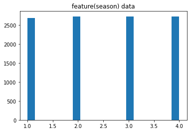

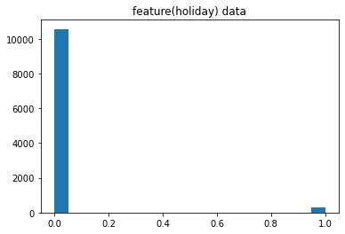

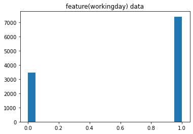

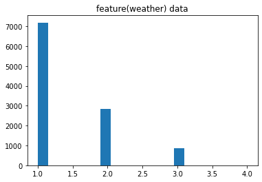

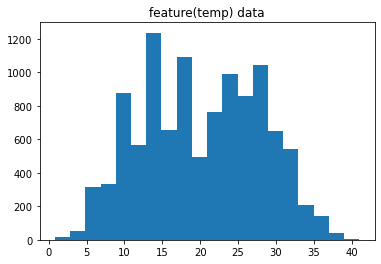

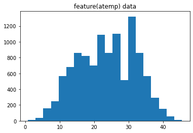

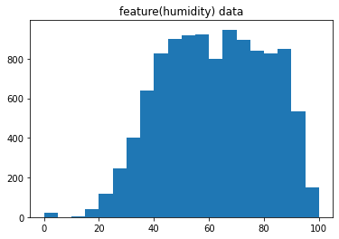

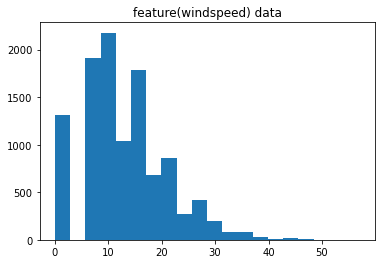

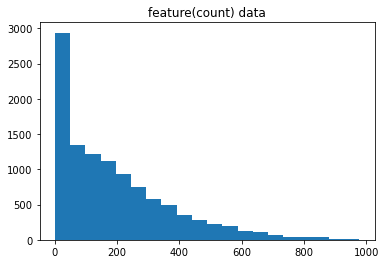

```python
cols_to_log = ["season", "holiday", "workingday","weather", "temp", "atemp","humidity", "windspeed", "count"]
for colname in cols_to_log:
    plt.hist(data[colname], bins=20)
    plt.title(f'feature({colname}) data')
    plt.show()
```

## Inital Model - Train a model using AutoGluon’s Tabular Prediction - with no features

```python
# split data

# Separating features and the target column
X = data.copy()


# Splitting the data into train and test sets
X_train, X_test = train_test_split(X, test_size=0.20, random_state=1, shuffle=True)

X_train, X_val = train_test_split(X_train, test_size=0.25, random_state=1, shuffle=True)

print(X_train.shape, X_val.shape, X_test.shape, data_test.shape)
```

```
(6531, 10) (2177, 10) (2178, 10) (6493, 9)
```

```python
label = "count"
save_path = "/Users/murali/tmp/bike_preduction_models/"
time_limit=120

predictor_default= TabularPredictor(
    label=label, problem_type="regression", eval_metric="root_mean_squared_error", path=save_path
).fit(train_data=X_train,presets= "best_quality",verbosity=1, time_limit=time_limit)
```

[output not shown]

[output cut: 65 more lines]

[output not shown]

```python
predictor_default.leaderboard(X_train, silent=True)
```

|  | model | score_test | score_val | pred_time_test | pred_time_val | fit_time | pred_time_test_marginal | pred_time_val_marginal | fit_time_marginal | stack_level | can_infer | fit_order |
| --- | --- | --- | --- | --- | --- | --- | --- | --- | --- | --- | --- | --- |
| 0 | RandomForestMSE_BAG_L1 | -47.775843 | -129.974284 | 0.118668 | 0.200341 | 0.684844 | 0.118668 | 0.200341 | 0.684844 | 1 | True | 3 |
| 1 | ExtraTreesMSE_BAG_L1 | -49.486275 | -134.527512 | 0.145532 | 0.199952 | 0.477380 | 0.145532 | 0.199952 | 0.477380 | 1 | True | 5 |
| 2 | KNeighborsDist_BAG_L1 | -57.784959 | -170.379650 | 0.018336 | 0.020993 | 0.004589 | 0.018336 | 0.020993 | 0.004589 | 1 | True | 2 |
| 3 | WeightedEnsemble_L2 | -68.604650 | -128.749897 | 0.713318 | 0.328748 | 57.445428 | 0.002023 | 0.000261 | 0.127603 | 2 | True | 8 |
| 4 | NeuralNetFastAI_BAG_L2 | -82.494877 | -127.946302 | 3.131294 | 1.475361 | 106.726164 | 0.581769 | 0.122559 | 29.313652 | 2 | True | 12 |
| 5 | WeightedEnsemble_L3 | -84.058703 | -126.968208 | 3.247775 | 1.702011 | 114.096991 | 0.001304 | 0.000261 | 0.081441 | 3 | True | 13 |
| 6 | CatBoost_BAG_L2 | -86.100652 | -127.651573 | 2.579186 | 1.374644 | 84.130393 | 0.029661 | 0.021842 | 6.717881 | 2 | True | 10 |
| 7 | ExtraTreesMSE_BAG_L2 | -88.630353 | -129.495502 | 2.635041 | 1.557350 | 77.984017 | 0.085516 | 0.204548 | 0.571505 | 2 | True | 11 |
| 8 | RandomForestMSE_BAG_L2 | -89.991111 | -131.371927 | 2.653845 | 1.559069 | 79.230139 | 0.104320 | 0.206267 | 1.817626 | 2 | True | 9 |
| 9 | CatBoost_BAG_L1 | -112.386856 | -134.173745 | 0.037226 | 0.021320 | 17.398912 | 0.037226 | 0.021320 | 17.398912 | 1 | True | 4 |
| 10 | KNeighborsUnif_BAG_L1 | -131.090903 | -161.178257 | 0.020165 | 0.019464 | 0.005486 | 0.020165 | 0.019464 | 0.005486 | 1 | True | 1 |
| 11 | NeuralNetFastAI_BAG_L1 | -131.851340 | -138.635724 | 0.555401 | 0.106826 | 39.234069 | 0.555401 | 0.106826 | 39.234069 | 1 | True | 6 |
| 12 | NeuralNetMXNet_BAG_L1 | -151.082221 | -166.768155 | 1.654197 | 0.783907 | 19.607232 | 1.654197 | 0.783907 | 19.607232 | 1 | True | 7 |

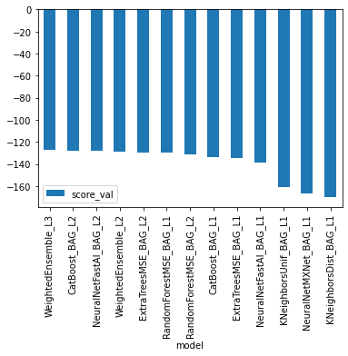

```python
# Output the model's `score_val` in a bar chart to compare performance
predictor_default.leaderboard(silent=True).plot(kind="bar", x="model", y="score_val")
```

```python
# Evaluate the models performance on the test dataset
performance = predictor_default.evaluate(X_test)
performance
```

```
{'root_mean_squared_error': -130.03564304969476,
 'mean_squared_error': -16909.268463347737,
 'mean_absolute_error': -89.69565330064002,
 'r2': 0.5041289692763076,
 'pearsonr': 0.7100884941690905,
 'median_absolute_error': -59.740936279296875}
```

```python
file_name = "predictor_default.csv"
genrerate_submit_data(predictor_default, file_name)
```

```
genrating predictor_default.csv for kaggle submission

Total negative values :

datetime    0
count       0
dtype: int64

After replace negative values :

datetime    0
count       0
dtype: int64
```

|  | datetime | count |
| --- | --- | --- |
| 770 | 2011-04-21 02:00:00 | 195.0 |
| 496 | 2011-03-21 13:00:00 | 188.0 |
| 3796 | 2012-03-22 00:00:00 | 132.0 |
| 5929 | 2012-10-31 09:00:00 | 123.0 |
| 1088 | 2011-05-23 08:00:00 | 168.0 |
| 6475 | 2012-12-31 06:00:00 | 130.0 |
| 5895 | 2012-10-28 11:00:00 | 398.0 |
| 689 | 2011-03-29 17:00:00 | 144.0 |
| 810 | 2011-04-22 18:00:00 | 46.0 |
| 1542 | 2011-06-30 06:00:00 | 159.0 |

```
csv file predictor_default.csv generated
```

#### Submit to competition's page - `My Submissions`

```python
!kaggle competitions submit -c bike-sharing-demand -f predictor_default.csv -m "default autogluon.tabular"
```

```python
!kaggle competitions submissions -c bike-sharing-demand | tail -n +1 | head -n 4
```

## Exploratory Data Analysis and Creating an additional feature

```python
# Extracting features from datetime
data["dt_hour"] = data["datetime"].dt.hour
data["dt_year"] = data["datetime"].dt.year
data["dt_month"] = data["datetime"].dt.month
data["dt_day"] = data["datetime"].dt.day
data["dt_dayofweek"] = data["datetime"].dt.dayofweek
data["dt_quarter"] = data["datetime"].dt.quarter

## submission data

data_test["dt_hour"] = data_test["datetime"].dt.hour
data_test["dt_year"] = data_test["datetime"].dt.year
data_test["dt_month"] = data_test["datetime"].dt.month
data_test["dt_day"] = data_test["datetime"].dt.day
data_test["dt_dayofweek"] = data_test["datetime"].dt.dayofweek
data_test["dt_quarter"] = data_test["datetime"].dt.quarter
```

```python
data.info()
```

```
<class 'pandas.core.frame.DataFrame'>
RangeIndex: 10886 entries, 0 to 10885
Data columns (total 16 columns):
 #   Column        Non-Null Count  Dtype
---  ------        --------------  -----
 0   datetime      10886 non-null  datetime64[ns]
 1   season        10886 non-null  int64
 2   holiday       10886 non-null  int64
 3   workingday    10886 non-null  int64
 4   weather       10886 non-null  int64
 5   temp          10886 non-null  float64
 6   atemp         10886 non-null  float64
 7   humidity      10886 non-null  int64
 8   windspeed     10886 non-null  float64
 9   count         10886 non-null  int64
 10  dt_hour       10886 non-null  int64
 11  dt_year       10886 non-null  int64
 12  dt_month      10886 non-null  int64
 13  dt_day        10886 non-null  int64
 14  dt_dayofweek  10886 non-null  int64
 15  dt_quarter    10886 non-null  int64
dtypes: datetime64[ns](1), float64(3), int64(12)
memory usage: 1.3 MB
```

```python
data.sample(10)
```

|  | datetime | season | holiday | workingday | weather | temp | atemp | humidity | windspeed | count | dt_hour | dt_year | dt_month | dt_day | dt_dayofweek | dt_quarter |
| --- | --- | --- | --- | --- | --- | --- | --- | --- | --- | --- | --- | --- | --- | --- | --- | --- |
| 4827 | 2011-11-14 05:00:00 | 4 | 0 | 1 | 2 | 18.04 | 21.970 | 67 | 16.9979 | 19 | 5 | 2011 | 11 | 14 | 0 | 4 |
| 5117 | 2011-12-07 07:00:00 | 4 | 0 | 1 | 3 | 18.04 | 21.970 | 100 | 7.0015 | 46 | 7 | 2011 | 12 | 7 | 2 | 4 |
| 1953 | 2011-05-08 07:00:00 | 2 | 0 | 0 | 2 | 18.86 | 22.725 | 82 | 0.0000 | 23 | 7 | 2011 | 5 | 8 | 6 | 2 |
| 8732 | 2012-08-06 05:00:00 | 3 | 0 | 1 | 1 | 28.70 | 33.335 | 79 | 12.9980 | 25 | 5 | 2012 | 8 | 6 | 0 | 3 |
| 768 | 2011-02-15 10:00:00 | 1 | 0 | 1 | 1 | 9.84 | 10.605 | 27 | 19.0012 | 52 | 10 | 2011 | 2 | 15 | 1 | 1 |
| 7101 | 2012-04-14 06:00:00 | 2 | 0 | 0 | 1 | 13.94 | 16.665 | 76 | 11.0014 | 21 | 6 | 2012 | 4 | 14 | 5 | 2 |
| 950 | 2011-03-04 01:00:00 | 1 | 0 | 1 | 2 | 7.38 | 9.090 | 64 | 12.9980 | 4 | 1 | 2011 | 3 | 4 | 4 | 1 |
| 2195 | 2011-05-18 09:00:00 | 2 | 0 | 1 | 3 | 22.96 | 26.515 | 83 | 16.9979 | 202 | 9 | 2011 | 5 | 18 | 2 | 2 |
| 8711 | 2012-08-05 08:00:00 | 3 | 0 | 0 | 1 | 31.16 | 36.365 | 66 | 22.0028 | 108 | 8 | 2012 | 8 | 5 | 6 | 3 |
| 2101 | 2011-05-14 11:00:00 | 2 | 0 | 0 | 2 | 21.32 | 25.000 | 94 | 8.9981 | 279 | 11 | 2011 | 5 | 14 | 5 | 2 |

```python
## Deleting datetime column
data.drop("datetime", inplace=True, axis=1)
data_test.drop("datetime", inplace=True, axis=1)
```

### Summary of the data

```python
data.describe().T
```

|  | count | mean | std | min | 25% | 50% | 75% | max |
| --- | --- | --- | --- | --- | --- | --- | --- | --- |
| season | 10886.0 | 2.506614 | 1.116174 | 1.00 | 2.0000 | 3.000 | 4.0000 | 4.0000 |
| holiday | 10886.0 | 0.028569 | 0.166599 | 0.00 | 0.0000 | 0.000 | 0.0000 | 1.0000 |
| workingday | 10886.0 | 0.680875 | 0.466159 | 0.00 | 0.0000 | 1.000 | 1.0000 | 1.0000 |
| weather | 10886.0 | 1.418427 | 0.633839 | 1.00 | 1.0000 | 1.000 | 2.0000 | 4.0000 |
| temp | 10886.0 | 20.230860 | 7.791590 | 0.82 | 13.9400 | 20.500 | 26.2400 | 41.0000 |
| atemp | 10886.0 | 23.655084 | 8.474601 | 0.76 | 16.6650 | 24.240 | 31.0600 | 45.4550 |
| humidity | 10886.0 | 61.886460 | 19.245033 | 0.00 | 47.0000 | 62.000 | 77.0000 | 100.0000 |
| windspeed | 10886.0 | 12.799395 | 8.164537 | 0.00 | 7.0015 | 12.998 | 16.9979 | 56.9969 |
| count | 10886.0 | 191.574132 | 181.144454 | 1.00 | 42.0000 | 145.000 | 284.0000 | 977.0000 |
| dt_hour | 10886.0 | 11.541613 | 6.915838 | 0.00 | 6.0000 | 12.000 | 18.0000 | 23.0000 |
| dt_year | 10886.0 | 2011.501929 | 0.500019 | 2011.00 | 2011.0000 | 2012.000 | 2012.0000 | 2012.0000 |
| dt_month | 10886.0 | 6.521495 | 3.444373 | 1.00 | 4.0000 | 7.000 | 10.0000 | 12.0000 |
| dt_day | 10886.0 | 9.992559 | 5.476608 | 1.00 | 5.0000 | 10.000 | 15.0000 | 19.0000 |
| dt_dayofweek | 10886.0 | 3.013963 | 2.004585 | 0.00 | 1.0000 | 3.000 | 5.0000 | 6.0000 |
| dt_quarter | 10886.0 | 2.506614 | 1.116174 | 1.00 | 2.0000 | 3.000 | 4.0000 | 4.0000 |

## Bivariate Analysis

### Data correlation analysis

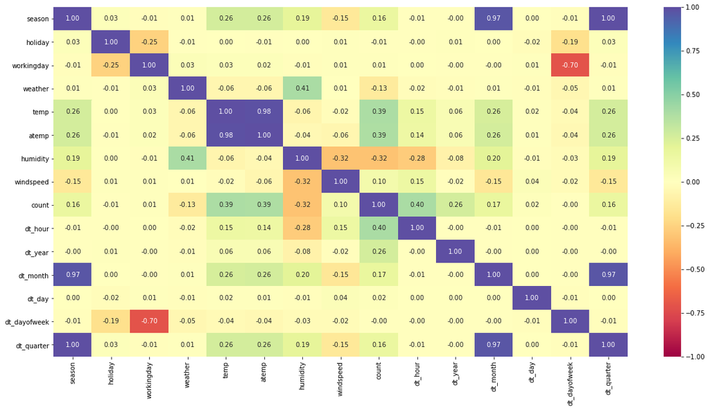

```python
plt.figure(figsize=(20, 10))
sns.heatmap(data.corr(), annot=True, vmin=-1, vmax=1, fmt=".2f", cmap="Spectral")
plt.show()
```

```python
# to scale the data using z-score
from sklearn.preprocessing import StandardScaler
## Dropping high corelated columns

data.drop("dt_quarter", inplace=True, axis=1)
data.drop("dt_day", inplace=True, axis=1)
data.drop("dt_year", inplace=True, axis=1)
data.drop("temp", inplace=True, axis=1)

## Delete from submission data
data_test.drop("dt_quarter", inplace=True, axis=1)
data_test.drop("dt_day", inplace=True, axis=1)
data_test.drop("dt_year", inplace=True, axis=1)
data_test.drop("temp", inplace=True, axis=1)
```

### convert static numerical to category types

```python
category_cols = [
    "season",
    "holiday",
    "workingday",
    "weather",
]

data[category_cols] = data[category_cols].astype("category")
data_test[category_cols] = data_test[category_cols].astype("category")
```

### Pair Plot

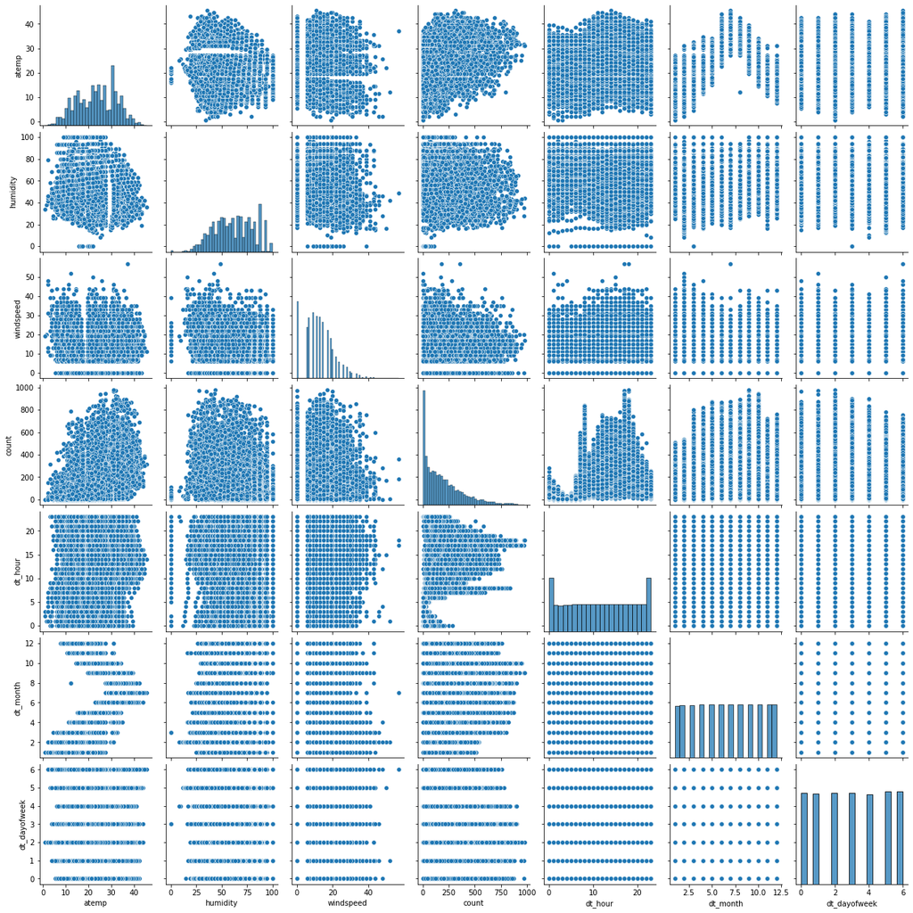

```python
sns.pairplot(data)
```

```python
data.describe().T
```

|  | count | mean | std | min | 25% | 50% | 75% | max |
| --- | --- | --- | --- | --- | --- | --- | --- | --- |
| atemp | 10886.0 | 23.655084 | 8.474601 | 0.76 | 16.6650 | 24.240 | 31.0600 | 45.4550 |
| humidity | 10886.0 | 61.886460 | 19.245033 | 0.00 | 47.0000 | 62.000 | 77.0000 | 100.0000 |
| windspeed | 10886.0 | 12.799395 | 8.164537 | 0.00 | 7.0015 | 12.998 | 16.9979 | 56.9969 |
| count | 10886.0 | 191.574132 | 181.144454 | 1.00 | 42.0000 | 145.000 | 284.0000 | 977.0000 |
| dt_hour | 10886.0 | 11.541613 | 6.915838 | 0.00 | 6.0000 | 12.000 | 18.0000 | 23.0000 |
| dt_month | 10886.0 | 6.521495 | 3.444373 | 1.00 | 4.0000 | 7.000 | 10.0000 | 12.0000 |
| dt_dayofweek | 10886.0 | 3.013963 | 2.004585 | 0.00 | 1.0000 | 3.000 | 5.0000 | 6.0000 |

```python
data_test.describe().T
```

|  | count | mean | std | min | 25% | 50% | 75% | max |
| --- | --- | --- | --- | --- | --- | --- | --- | --- |
| atemp | 6493.0 | 24.012865 | 8.782741 | 0.0 | 16.6650 | 25.0000 | 31.0600 | 50.0000 |
| humidity | 6493.0 | 64.125212 | 19.293391 | 16.0 | 49.0000 | 65.0000 | 81.0000 | 100.0000 |
| windspeed | 6493.0 | 12.631157 | 8.250151 | 0.0 | 7.0015 | 11.0014 | 16.9979 | 55.9986 |
| dt_hour | 6493.0 | 11.555367 | 6.912526 | 0.0 | 6.0000 | 12.0000 | 18.0000 | 23.0000 |
| dt_month | 6493.0 | 6.565070 | 3.429462 | 1.0 | 4.0000 | 7.0000 | 10.0000 | 12.0000 |
| dt_dayofweek | 6493.0 | 3.007239 | 1.997714 | 0.0 | 1.0000 | 3.0000 | 5.0000 | 6.0000 |

```python
data.sample(10)
```

|  | season | holiday | workingday | weather | atemp | humidity | windspeed | count | dt_hour | dt_month | dt_dayofweek |
| --- | --- | --- | --- | --- | --- | --- | --- | --- | --- | --- | --- |
| 10062 | 4 | 0 | 0 | 1 | 20.455 | 40 | 15.0013 | 449 | 15 | 11 | 6 |
| 3929 | 3 | 0 | 1 | 1 | 34.090 | 62 | 11.0014 | 586 | 18 | 9 | 2 |
| 6416 | 1 | 0 | 0 | 1 | 16.665 | 34 | 23.9994 | 332 | 14 | 3 | 6 |
| 3368 | 3 | 0 | 1 | 1 | 31.820 | 61 | 0.0000 | 119 | 6 | 8 | 2 |
| 10286 | 4 | 0 | 1 | 1 | 12.120 | 56 | 19.0012 | 24 | 0 | 11 | 2 |
| 10059 | 4 | 0 | 0 | 1 | 19.695 | 46 | 15.0013 | 504 | 12 | 11 | 6 |
| 1168 | 1 | 0 | 0 | 1 | 20.455 | 50 | 27.9993 | 44 | 9 | 3 | 6 |
| 10017 | 4 | 0 | 1 | 2 | 19.695 | 43 | 22.0028 | 522 | 18 | 11 | 4 |
| 1459 | 2 | 0 | 1 | 1 | 25.760 | 28 | 27.9993 | 169 | 16 | 4 | 2 |
| 9821 | 4 | 0 | 0 | 1 | 23.485 | 33 | 12.9980 | 597 | 14 | 10 | 5 |

```python
# function to compute adjusted R-squared
def adj_r2_score(predictors, targets, predictions):
    r2 = r2_score(targets, predictions)
    n = predictors.shape[0]
    k = predictors.shape[1]
    return 1 - ((1 - r2) * (n - 1) / (n - k - 1))


# function to compute MAPE
def mape_score(targets, predictions):
    return np.mean(np.abs(targets - predictions) / targets) * 100


# function to compute different metrics to check performance of a regression model
def model_performance_regression(model, predictors, target):
    """
    Function to compute different metrics to check regression model performance

    model: regressor
    predictors: independent variables
    target: dependent variable
    """

    # predicting using the independent variables
    pred = model.predict(predictors)

    r2 = r2_score(target, pred)  # to compute R-squared
    adjr2 = adj_r2_score(predictors, target, pred)  # to compute adjusted R-squared
    rmse = np.sqrt(mean_squared_error(target, pred))  # to compute RMSE
    mae = mean_absolute_error(target, pred)  # to compute MAE
    mape = mape_score(target, pred)  # to compute MAPE

    # creating a dataframe of metrics
    df_perf = pd.DataFrame(
        {
            "RMSE": rmse,
            "MAE": mae,
            "R-squared": r2,
            "Adj. R-squared": adjr2,
            "MAPE": mape,
        },
        index=[0],
    )

    return df_perf
```

```python
# before one hot encoding
data.info()
```

```
<class 'pandas.core.frame.DataFrame'>
RangeIndex: 10886 entries, 0 to 10885
Data columns (total 11 columns):
 #   Column        Non-Null Count  Dtype
---  ------        --------------  -----
 0   season        10886 non-null  category
 1   holiday       10886 non-null  category
 2   workingday    10886 non-null  category
 3   weather       10886 non-null  category
 4   atemp         10886 non-null  float64
 5   humidity      10886 non-null  int64
 6   windspeed     10886 non-null  float64
 7   count         10886 non-null  int64
 8   dt_hour       10886 non-null  int64
 9   dt_month      10886 non-null  int64
 10  dt_dayofweek  10886 non-null  int64
dtypes: category(4), float64(2), int64(5)
memory usage: 638.6 KB
```

### one hot encoding for category types before model building

```python
data = pd.get_dummies(data, drop_first=True)
data_test = pd.get_dummies(data_test, drop_first=True)
```

```python
# after one hot encoding
data.info()
```

```
<class 'pandas.core.frame.DataFrame'>
RangeIndex: 10886 entries, 0 to 10885
Data columns (total 15 columns):
 #   Column        Non-Null Count  Dtype
---  ------        --------------  -----
 0   atemp         10886 non-null  float64
 1   humidity      10886 non-null  int64
 2   windspeed     10886 non-null  float64
 3   count         10886 non-null  int64
 4   dt_hour       10886 non-null  int64
 5   dt_month      10886 non-null  int64
 6   dt_dayofweek  10886 non-null  int64
 7   season_2      10886 non-null  uint8
 8   season_3      10886 non-null  uint8
 9   season_4      10886 non-null  uint8
 10  holiday_1     10886 non-null  uint8
 11  workingday_1  10886 non-null  uint8
 12  weather_2     10886 non-null  uint8
 13  weather_3     10886 non-null  uint8
 14  weather_4     10886 non-null  uint8
dtypes: float64(2), int64(5), uint8(8)
memory usage: 680.5 KB
```

```python
# split data

# Separating features and the target column
X = data.drop("count", axis=1)
y = data["count"]

# Splitting the data into train and test sets in 70:30 ratio
X_train, X_test, y_train, y_test = train_test_split(
    X, y, test_size=0.30, random_state=1, shuffle=True
)
print(X_train.shape, X_test.shape, data_test.shape)
```

```
(7620, 14) (3266, 14) (6493, 14)
```

### Random Forest Model - to get base score

```python
rf_estimator = RandomForestRegressor(random_state=1)
rf_estimator.fit(X_train, y_train)
```

```
RandomForestRegressor(random_state=1)
```

```python
rf_estimator_model_train_perf = model_performance_regression(
    rf_estimator, X_train, y_train
)
print("Train performance \n")
display(rf_estimator_model_train_perf)
```

```
Train performance
```

|  | RMSE | MAE | R-squared | Adj. R-squared | MAPE |
| --- | --- | --- | --- | --- | --- |
| 0 | 25.099874 | 16.284524 | 0.980554 | 0.980518 | 16.161992 |

```python
rf_estimator_model_test_perf = model_performance_regression(
    rf_estimator, X_test, y_test
)
print("Testing performance \n")
display(rf_estimator_model_test_perf)
```

```
Testing performance
```

|  | RMSE | MAE | R-squared | Adj. R-squared | MAPE |
| --- | --- | --- | --- | --- | --- |
| 0 | 65.870222 | 44.316571 | 0.87136 | 0.870806 | 42.040721 |

```python
rf_tuned = rf_estimator
```

```python
rf_tuned_model_train_perf = model_performance_regression(rf_tuned, X_train, y_train)
print("Training performance \n")
display(rf_tuned_model_train_perf)
```

```
Training performance
```

|  | RMSE | MAE | R-squared | Adj. R-squared | MAPE |
| --- | --- | --- | --- | --- | --- |
| 0 | 25.099874 | 16.284524 | 0.980554 | 0.980518 | 16.161992 |

```python
rf_tuned_model_test_perf = model_performance_regression(rf_tuned, X_test, y_test)
print("Testing performance \n")
display(rf_tuned_model_test_perf)
```

```
Testing performance
```

|  | RMSE | MAE | R-squared | Adj. R-squared | MAPE |
| --- | --- | --- | --- | --- | --- |
| 0 | 65.870222 | 44.316571 | 0.87136 | 0.870806 | 42.040721 |

```python
file_name = "rf_tuned.csv"
genrerate_submit_data(rf_tuned,file_name)
```

```
genrating rf_tuned.csv for kaggle submission

Total negative values :

datetime    0
count       0
dtype: int64

After replace negative values :

datetime    0
count       0
dtype: int64
```

|  | datetime | count |
| --- | --- | --- |
| 3704 | 2012-02-28 03:00:00 | 3.0 |
| 1156 | 2011-05-26 04:00:00 | 5.0 |
| 808 | 2011-04-22 16:00:00 | 142.0 |
| 4913 | 2012-07-22 13:00:00 | 397.0 |
| 593 | 2011-03-25 15:00:00 | 128.0 |
| 3150 | 2011-12-28 23:00:00 | 66.0 |
| 5344 | 2012-08-28 12:00:00 | 187.0 |
| 1906 | 2011-08-22 10:00:00 | 156.0 |
| 4263 | 2012-04-29 11:00:00 | 397.0 |
| 2668 | 2011-10-31 17:00:00 | 557.0 |

```
csv file rf_tuned.csv generated
```

#### View submission via the command line or in the web browser under the competition's page - `My Submissions`

```python
!kaggle competitions submit -c bike-sharing-demand -f rf_tuned.csv -m "default random forest"
```

```python
!kaggle competitions submissions -c bike-sharing-demand | tail -n +1 | head -n 4
```

### Observation on Default Random Forest Model

#### Updated score of `0.519` - Much better than intial Model with no features

## Train a model using AutoGluon’s Tabular Prediction - with new features

```python
# split data

# Separating features and the target column
X = data.copy()


# Splitting the data into train and test sets
X_train, X_test = train_test_split(X, test_size=0.20, random_state=1, shuffle=True)

X_train, X_val = train_test_split(X_train, test_size=0.25, random_state=1, shuffle=True)

print(X_train.shape, X_val.shape, X_test.shape, data_test.shape)
```

```
(6531, 15) (2177, 15) (2178, 15) (6493, 14)
```

```python
label = "count"
save_path = "/Users/murali/tmp/bike_preduction_models/"
time_limit=120

predictor_default_features= TabularPredictor(
    label=label, problem_type="regression", eval_metric="root_mean_squared_error", path=save_path
).fit(train_data=X_train,presets= "best_quality",verbosity=1, time_limit=time_limit)
```

[output not shown]

[output cut: 65 more lines]

[output not shown]

```python
predictor_default_features.leaderboard(X_train, silent=True)
```

|  | model | score_test | score_val | pred_time_test | pred_time_val | fit_time | pred_time_test_marginal | pred_time_val_marginal | fit_time_marginal | stack_level | can_infer | fit_order |
| --- | --- | --- | --- | --- | --- | --- | --- | --- | --- | --- | --- | --- |
| 0 | KNeighborsDist_BAG_L1 | -3.358430 | -115.205577 | 0.031997 | 0.033247 | 0.004700 | 0.031997 | 0.033247 | 0.004700 | 1 | True | 2 |
| 1 | ExtraTreesMSE_BAG_L1 | -24.760728 | -66.855983 | 0.157057 | 0.197559 | 0.494511 | 0.157057 | 0.197559 | 0.494511 | 1 | True | 5 |
| 2 | RandomForestMSE_BAG_L1 | -25.129585 | -67.834025 | 0.116773 | 0.200590 | 0.684603 | 0.116773 | 0.200590 | 0.684603 | 1 | True | 3 |
| 3 | NeuralNetFastAI_BAG_L2 | -33.308054 | -61.636361 | 1.620887 | 0.731261 | 107.962830 | 0.625853 | 0.126064 | 31.117575 | 2 | True | 11 |
| 4 | WeightedEnsemble_L3 | -34.775464 | -60.513137 | 1.912756 | 1.162741 | 116.106669 | 0.001532 | 0.000262 | 0.082677 | 3 | True | 12 |
| 5 | CatBoost_BAG_L2 | -35.086441 | -60.961547 | 1.031008 | 0.628396 | 82.763584 | 0.035974 | 0.023200 | 5.918329 | 2 | True | 9 |
| 6 | WeightedEnsemble_L2 | -36.676376 | -60.718896 | 0.936594 | 0.539570 | 76.947095 | 0.002393 | 0.000281 | 0.111741 | 2 | True | 7 |
| 7 | CatBoost_BAG_L1 | -39.264631 | -60.957292 | 0.057712 | 0.029464 | 42.480232 | 0.057712 | 0.029464 | 42.480232 | 1 | True | 4 |
| 8 | ExtraTreesMSE_BAG_L2 | -39.497468 | -61.757955 | 1.097943 | 0.808999 | 77.464107 | 0.102909 | 0.203803 | 0.618852 | 2 | True | 10 |
| 9 | RandomForestMSE_BAG_L2 | -41.062931 | -62.101056 | 1.146488 | 0.809412 | 78.369236 | 0.151454 | 0.204216 | 1.523981 | 2 | True | 8 |
| 10 | NeuralNetFastAI_BAG_L1 | -67.315190 | -77.727286 | 0.602659 | 0.111676 | 33.176008 | 0.602659 | 0.111676 | 33.176008 | 1 | True | 6 |
| 11 | KNeighborsUnif_BAG_L1 | -95.345181 | -118.538726 | 0.028836 | 0.032660 | 0.005201 | 0.028836 | 0.032660 | 0.005201 | 1 | True | 1 |

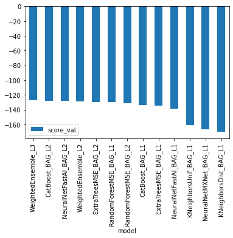

```python
# Output the model's `score_val` in a bar chart to compare performance
predictor_default.leaderboard(silent=True).plot(kind="bar", x="model", y="score_val")
```

```python
# Evaluate the models performance on the test dataset
performance = predictor_default_features.evaluate(X_test)
performance
```

```
{'root_mean_squared_error': -59.87460511187596,
 'mean_squared_error': -3584.9683373030944,
 'mean_absolute_error': -39.876072541631835,
 'r2': 0.8948693760239502,
 'pearsonr': 0.9461857988030279,
 'median_absolute_error': -23.65253734588623}
```

```python
file_name = "predictor_default_features.csv"
genrerate_submit_data(predictor_default_features, file_name)
```

```
genrating predictor_default_features.csv for kaggle submission

Total negative values :

datetime    1
count       1
dtype: int64

After replace negative values :

datetime    0
count       0
dtype: int64
```

|  | datetime | count |
| --- | --- | --- |
| 1041 | 2011-05-21 09:00:00 | 292.0 |
| 1608 | 2011-07-22 00:00:00 | 82.0 |
| 5633 | 2012-09-28 13:00:00 | 352.0 |
| 1962 | 2011-08-24 18:00:00 | 643.0 |
| 4158 | 2012-04-25 02:00:00 | 7.0 |
| 629 | 2011-03-27 03:00:00 | 8.0 |
| 840 | 2011-04-24 00:00:00 | 88.0 |
| 1474 | 2011-06-27 10:00:00 | 191.0 |
| 2187 | 2011-09-22 16:00:00 | 282.0 |
| 5933 | 2012-10-31 13:00:00 | 274.0 |

```
csv file predictor_default_features.csv generated
```

#### Submit to competition's page - `My Submissions`

```python
!kaggle competitions submit -c bike-sharing-demand -f predictor_default_features.csv -m "default autogluon.tabular with new features"
```

```python
!kaggle competitions submissions -c bike-sharing-demand | tail -n +1 | head -n 4
```

### Observation on Initial Model

#### Updated score of `0.5231` and with `'root_mean_squared_error': -59.874` - great improvement compared to initial model built with no features, Lets looks for more improvement opportunity

```python
# parameters tuning
label = "count"
save_path = "/Users/murali/tmp/bike_preduction_models/"

metric = "root_mean_squared_error"

train_data = X_train.copy()
val_data = X_val.copy()

time_limit = 5 * 60  # train various models for ~2 min
num_trials = (
    15  # try at most 15 different hyperparameter configurations for each type of model
)
search_strategy = "auto"  # to tune hyperparameters using Bayesian optimization routine with a local scheduler


gbm_options = {  # specifies non-default hyperparameter values for lightGBM gradient boosted trees
    "num_boost_round": 100,  # number of boosting rounds (controls training time of GBM models)
    "num_leaves": ag.space.Int(
        lower=4, upper=100, default=35
    ),  # number of leaves in trees (integer hyperparameter)
}

knn_options = { "n_neighbors" : ag.space.Int(
        lower=3, upper=10, default=5
    )
              }

hyperparameter_tune_kwargs = (
    {  # HPO is not performed unless hyperparameter_tune_kwargs is specified
        "num_trials": num_trials,
        "scheduler": "local",
        "searcher": search_strategy,
    }
)

hyperparameters = {
    "GBM": gbm_options,
    #"KNN":knn_options
}  # hyperparameters of each model type

presets = ['good_quality_faster_inference_only_refit', 'optimize_for_deployment']
```

```python
predictor_tuned = TabularPredictor(
    label=label, problem_type="regression", eval_metric=metric, path=save_path
).fit(
    train_data,
    tuning_data=val_data,
    verbosity=2,
    time_limit=time_limit,
)
```

```
Warning: path already exists! This predictor may overwrite an existing predictor! path="/Users/murali/tmp/bike_preduction_models/"
Beginning AutoGluon training ... Time limit = 300s
AutoGluon will save models to "/Users/murali/tmp/bike_preduction_models/"
AutoGluon Version:  0.3.1
Train Data Rows:    6531
Train Data Columns: 14
Tuning Data Rows:    2177
Tuning Data Columns: 14
Preprocessing data ...
Using Feature Generators to preprocess the data ...
Fitting AutoMLPipelineFeatureGenerator...
	Available Memory:                    1238.38 MB
	Train Data (Original)  Memory Usage: 0.49 MB (0.0% of available memory)
	Inferring data type of each feature based on column values. Set feature_metadata_in to manually specify special dtypes of the features.
	Stage 1 Generators:
		Fitting AsTypeFeatureGenerator...
			Note: Converting 8 features to boolean dtype as they only contain 2 unique values.
	Stage 2 Generators:
		Fitting FillNaFeatureGenerator...
	Stage 3 Generators:
		Fitting IdentityFeatureGenerator...
	Stage 4 Generators:
		Fitting DropUniqueFeatureGenerator...
	Types of features in original data (raw dtype, special dtypes):
		('float', []) :  2 | ['atemp', 'windspeed']
		('int', [])   : 12 | ['humidity', 'dt_hour', 'dt_month', 'dt_dayofweek', 'season_2', ...]
	Types of features in processed data (raw dtype, special dtypes):
		('float', [])     : 2 | ['atemp', 'windspeed']
		('int', [])       : 4 | ['humidity', 'dt_hour', 'dt_month', 'dt_dayofweek']
		('int', ['bool']) : 8 | ['season_2', 'season_3', 'season_4', 'holiday_1', 'workingday_1', ...]
	0.0s = Fit runtime
	14 features in original data used to generate 14 features in processed data.
	Train Data (Processed) Memory Usage: 0.49 MB (0.0% of available memory)
Data preprocessing and feature engineering runtime = 0.05s ...
AutoGluon will gauge predictive performance using evaluation metric: 'root_mean_squared_error'
	To change this, specify the eval_metric argument of fit()
Fitting 11 L1 models ...
Fitting model: KNeighborsUnif ... Training model for up to 299.95s of the 299.95s of remaining time.
	-118.2246	 = Validation score   (root_mean_squared_error)
	0.01s	 = Training   runtime
```

[output cut: 65 more lines]

```
Fitting model: NeuralNetMXNet ... Training model for up to 287.2s of the 287.2s of remaining time.
	-61.3812	 = Validation score   (root_mean_squared_error)
	65.48s	 = Training   runtime
	0.14s	 = Validation runtime
Fitting model: LightGBMLarge ... Training model for up to 221.58s of the 221.58s of remaining time.
	Warning: Exception caused LightGBMLarge to fail during training (ImportError)... Skipping this model.
		`import lightgbm` failed. If you are using Mac OSX, Please try 'brew install libomp'. Detailed info: dlopen(/Users/murali/opt/anaconda3/lib/python3.8/site-packages/lightgbm/lib_lightgbm.so, 0x0006): Library not loaded: /usr/local/opt/libomp/lib/libomp.dylib
  Referenced from: /Users/murali/opt/anaconda3/lib/python3.8/site-packages/lightgbm/lib_lightgbm.so
  Reason: tried: '/usr/local/opt/libomp/lib/libomp.dylib' (no such file), '/usr/local/lib/libomp.dylib' (no such file), '/usr/lib/libomp.dylib' (no such file)
Fitting model: WeightedEnsemble_L2 ... Training model for up to 299.95s of the 221.1s of remaining time.
	-57.1956	 = Validation score   (root_mean_squared_error)
	0.11s	 = Training   runtime
	0.0s	 = Validation runtime
AutoGluon training complete, total runtime = 79.02s ...
TabularPredictor saved. To load, use: predictor = TabularPredictor.load("/Users/murali/tmp/bike_preduction_models/")
```

```
Evaluation: root_mean_squared_error on test data: -59.60090004015911
	Note: Scores are always higher_is_better. This metric score can be multiplied by -1 to get the metric value.
Evaluations on test data:
{
    "root_mean_squared_error": -59.60090004015911,
    "mean_squared_error": -3552.2672855970486,
    "mean_absolute_error": -38.69714665372537,
    "r2": 0.895828347386335,
    "pearsonr": 0.9474522536017896,
    "median_absolute_error": -22.55938720703125
}
```

```
{'root_mean_squared_error': -59.60090004015911,
 'mean_squared_error': -3552.2672855970486,
 'mean_absolute_error': -38.69714665372537,
 'r2': 0.895828347386335,
 'pearsonr': 0.9474522536017896,
 'median_absolute_error': -22.55938720703125}
```

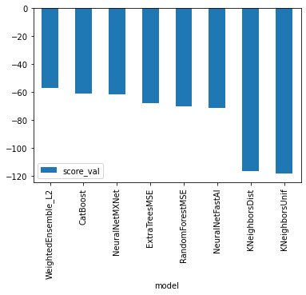

```python
# Output the model's `score_val` in a bar chart to compare performance
predictor_tuned.leaderboard(silent=True).plot(kind="bar", x="model", y="score_val")

# Evaluate the models performance on the test dataset
performance = predictor_tuned.evaluate(X_test)
performance
```

```python
predictor_tuned.leaderboard(train_data, silent=True)
```

|  | model | score_test | score_val | pred_time_test | pred_time_val | fit_time | pred_time_test_marginal | pred_time_val_marginal | fit_time_marginal | stack_level | can_infer | fit_order |
| --- | --- | --- | --- | --- | --- | --- | --- | --- | --- | --- | --- | --- |
| 0 | KNeighborsDist | -3.358430 | -116.086998 | 0.033313 | 0.013071 | 0.006504 | 0.033313 | 0.013071 | 0.006504 | 1 | True | 2 |
| 1 | ExtraTreesMSE | -24.760728 | -67.714952 | 0.109799 | 0.035998 | 0.479871 | 0.109799 | 0.035998 | 0.479871 | 1 | True | 5 |
| 2 | RandomForestMSE | -25.129585 | -69.889124 | 0.113634 | 0.035627 | 0.654621 | 0.113634 | 0.035627 | 0.654621 | 1 | True | 3 |
| 3 | WeightedEnsemble_L2 | -33.727501 | -57.195619 | 0.240382 | 0.141323 | 71.836111 | 0.001805 | 0.000246 | 0.108958 | 2 | True | 8 |
| 4 | CatBoost | -34.307308 | -61.150120 | 0.007945 | 0.003254 | 6.244961 | 0.007945 | 0.003254 | 6.244961 | 1 | True | 4 |
| 5 | NeuralNetMXNet | -39.392206 | -61.381219 | 0.230632 | 0.137823 | 65.482192 | 0.230632 | 0.137823 | 65.482192 | 1 | True | 7 |
| 6 | NeuralNetFastAI | -63.146813 | -71.389938 | 0.060818 | 0.021804 | 5.016333 | 0.060818 | 0.021804 | 5.016333 | 1 | True | 6 |
| 7 | KNeighborsUnif | -95.345181 | -118.224571 | 0.031688 | 0.014745 | 0.008554 | 0.031688 | 0.014745 | 0.008554 | 1 | True | 1 |

```python
predictor_tuned.get_model_best()
```

```
'WeightedEnsemble_L2'
```

```python
predictor_tuned.feature_importance(data=train_data)
```

```
Computing feature importance via permutation shuffling for 14 features using 1000 rows with 3 shuffle sets...
	5.87s	= Expected runtime (1.96s per shuffle set)
	1.59s	= Actual runtime (Completed 3 of 3 shuffle sets)
```

|  | importance | stddev | p_value | n | p99_high | p99_low |
| --- | --- | --- | --- | --- | --- | --- |
| dt_hour | 168.940105 | 7.585250 | 0.000336 | 3 | 212.404427 | 125.475783 |
| atemp | 64.325955 | 0.813567 | 0.000027 | 3 | 68.987782 | 59.664128 |
| humidity | 42.816824 | 7.389457 | 0.004891 | 3 | 85.159232 | 0.474417 |
| dt_dayofweek | 40.335661 | 1.915751 | 0.000376 | 3 | 51.313125 | 29.358198 |
| dt_month | 38.876843 | 3.496361 | 0.001343 | 3 | 58.911381 | 18.842305 |
| workingday_1 | 34.454434 | 4.417503 | 0.002717 | 3 | 59.767215 | 9.141654 |
| windspeed | 16.627719 | 1.305716 | 0.001025 | 3 | 24.109616 | 9.145821 |
| season_3 | 12.675199 | 1.005228 | 0.001045 | 3 | 18.435266 | 6.915133 |
| season_4 | 12.650267 | 0.750571 | 0.000586 | 3 | 16.951122 | 8.349412 |
| season_2 | 11.715249 | 1.184008 | 0.001694 | 3 | 18.499744 | 4.930755 |
| weather_3 | 10.063969 | 4.009185 | 0.024520 | 3 | 33.037044 | -12.909107 |
| weather_2 | 8.742320 | 1.813297 | 0.007020 | 3 | 19.132713 | -1.648073 |
| holiday_1 | 2.277161 | 0.232770 | 0.001732 | 3 | 3.610961 | 0.943360 |
| weather_4 | 0.055017 | 0.095292 | 0.211325 | 3 | 0.601053 | -0.491018 |

```python
file_name = "predictor_tuned.csv"
genrerate_submit_data(predictor_tuned, file_name)
```

```
genrating predictor_tuned.csv for kaggle submission

Total negative values :

datetime    191
count       191
dtype: int64

After replace negative values :

datetime    0
count       0
dtype: int64
```

|  | datetime | count |
| --- | --- | --- |
| 4907 | 2012-07-22 07:00:00 | 35.0 |
| 2714 | 2011-11-21 15:00:00 | 145.0 |
| 2389 | 2011-10-20 02:00:00 | 24.0 |
| 1664 | 2011-07-24 08:00:00 | 156.0 |
| 1928 | 2011-08-23 08:00:00 | 557.0 |
| 925 | 2011-04-27 13:00:00 | 142.0 |
| 2612 | 2011-10-29 09:00:00 | 59.0 |
| 3960 | 2012-03-28 20:00:00 | 333.0 |
| 88 | 2011-01-23 18:00:00 | 74.0 |
| 3761 | 2012-03-20 13:00:00 | 239.0 |

```
csv file predictor_tuned.csv generated
```

#### Submit to competition's page - `My Submissions`

```python
!kaggle competitions submit -c bike-sharing-demand -f predictor_tuned.csv -m "tuned autogluon.tabular"
```

```python
!kaggle competitions submissions -c bike-sharing-demand | tail -n +1 | head -n 4
```

### Observation on Tuned Model

#### Updated score of `0.654` and with `'root_mean_squared_error':-59.60` - great improvement compared to initial model - but not good as default model built with new features

## Train a model using AutoGluon’s Tabular Prediction with Stacking

```python
predictor_stack = TabularPredictor(
    label=label, problem_type="regression", eval_metric=metric, path=save_path
).fit(
    train_data,
    num_bag_folds=10,
    num_bag_sets=2,
    num_stack_levels=2,
    auto_stack=True,
    time_limit=120,
    hyperparameters={
        "NN": {"num_epochs": 2},
        "GBM": {"num_boost_round": 100, "learning_rate": ag.Real(0.01, 0.1)},
    },
)
```

[output not shown]

[output cut: 42 more lines]

```
	-230.2348	 = Validation score   (root_mean_squared_error)
	9.16s	 = Training   runtime
	1.1s	 = Validation runtime
Repeating k-fold bagging: 2/2
Fitting model: NeuralNetMXNet_BAG_L3 ... Training model for up to 68.62s of the 68.62s of remaining time.
	-219.2572	 = Validation score   (root_mean_squared_error)
	18.36s	 = Training   runtime
	2.19s	 = Validation runtime
Completed 2/2 k-fold bagging repeats ...
Fitting model: WeightedEnsemble_L4 ... Training model for up to 119.95s of the 58.3s of remaining time.
	-219.2572	 = Validation score   (root_mean_squared_error)
	0.0s	 = Training   runtime
	0.0s	 = Validation runtime
AutoGluon training complete, total runtime = 61.71s ...
TabularPredictor saved. To load, use: predictor = TabularPredictor.load("/Users/murali/tmp/bike_preduction_models/")
```

```python
predictor_stack.leaderboard(train_data, silent=True)
```

|  | model | score_test | score_val | pred_time_test | pred_time_val | fit_time | pred_time_test_marginal | pred_time_val_marginal | fit_time_marginal | stack_level | can_infer | fit_order |
| --- | --- | --- | --- | --- | --- | --- | --- | --- | --- | --- | --- | --- |
| 0 | NeuralNetMXNet_BAG_L2 | -209.129868 | -211.825559 | 9.040887 | 4.331316 | 36.467474 | 4.548846 | 2.168966 | 18.345623 | 2 | True | 3 |
| 1 | WeightedEnsemble_L3 | -209.129868 | -211.825559 | 9.041722 | 4.331601 | 36.468613 | 0.000835 | 0.000285 | 0.001139 | 3 | True | 4 |
| 2 | NeuralNetMXNet_BAG_L3 | -217.064736 | -219.257222 | 13.567709 | 6.523004 | 54.824123 | 4.526822 | 2.191688 | 18.356649 | 3 | True | 5 |
| 3 | WeightedEnsemble_L4 | -217.064736 | -219.257222 | 13.568482 | 6.523288 | 54.825486 | 0.000773 | 0.000285 | 0.001363 | 4 | True | 6 |
| 4 | NeuralNetMXNet_BAG_L1 | -231.468510 | -233.290015 | 4.492041 | 2.162349 | 18.121851 | 4.492041 | 2.162349 | 18.121851 | 1 | True | 1 |
| 5 | WeightedEnsemble_L2 | -231.468510 | -233.290015 | 4.493362 | 2.162625 | 18.122972 | 0.001321 | 0.000276 | 0.001121 | 2 | True | 2 |

```
Evaluation: root_mean_squared_error on test data: -211.2523084407959
	Note: Scores are always higher_is_better. This metric score can be multiplied by -1 to get the metric value.
Evaluations on test data:
{
    "root_mean_squared_error": -211.2523084407959,
    "mean_squared_error": -44627.537821565704,
    "mean_absolute_error": -189.08098397022874,
    "r2": -0.3087203166835937,
    "pearsonr": 0.5256659427899241,
    "median_absolute_error": -201.72705078125
}
```

```
{'root_mean_squared_error': -211.2523084407959,
 'mean_squared_error': -44627.537821565704,
 'mean_absolute_error': -189.08098397022874,
 'r2': -0.3087203166835937,
 'pearsonr': 0.5256659427899241,
 'median_absolute_error': -201.72705078125}
```

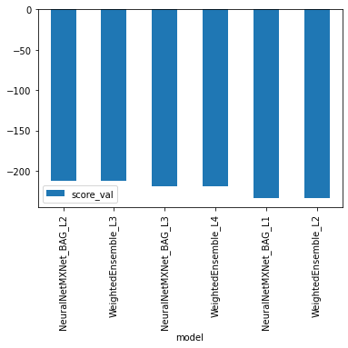

```python
# Output the model's `score_val` in a bar chart to compare performance
predictor_stack.leaderboard(silent=True).plot(kind="bar", x="model", y="score_val")

# Evaluate the models performance on the test dataset
performance = predictor_stack.evaluate(X_test)
performance
```

```python
file_name = "predictor_stack.csv"
genrerate_submit_data(predictor_stack, file_name)
```

```
genrating predictor_stack.csv for kaggle submission

Total negative values :

datetime    0
count       0
dtype: int64

After replace negative values :

datetime    0
count       0
dtype: int64
```

|  | datetime | count |
| --- | --- | --- |
| 2518 | 2011-10-25 11:00:00 | 350.0 |
| 6194 | 2012-11-30 11:00:00 | 323.0 |
| 5462 | 2012-09-21 10:00:00 | 382.0 |
| 125 | 2011-01-25 09:00:00 | 280.0 |
| 4176 | 2012-04-25 20:00:00 | 398.0 |
| 4946 | 2012-07-23 22:00:00 | 511.0 |
| 2080 | 2011-08-30 05:00:00 | 297.0 |
| 102 | 2011-01-24 09:00:00 | 266.0 |
| 752 | 2011-04-20 08:00:00 | 312.0 |
| 5975 | 2012-11-21 07:00:00 | 298.0 |

```
csv file predictor_stack.csv generated
```

#### Submit to competition's page - `My Submissions`

```python
!kaggle competitions submit -c bike-sharing-demand -f predictor_stack.csv -m "stacked autogluon.tabular"
```

```python
!kaggle competitions submissions -c bike-sharing-demand | tail -n +1 | head -n 4
```

### observation on stacking

- not good as inital model build on new features or hyper tuned model.

# Performance Report

### Top Scores

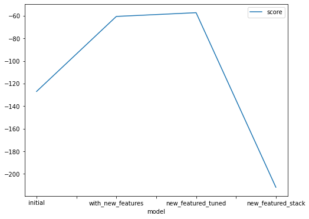

```python
# Taking the top model score
fig = (
    pd.DataFrame(
        {
            "model": [
                "initial",
                "with_new_features",
                "new_featured_tuned",
                "new_featured_stack",
            ],
            "score": [
                predictor_default.leaderboard(silent=True)["score_val"][0],
                predictor_default_features.leaderboard(silent=True)["score_val"][0],
                predictor_tuned.leaderboard(silent=True)["score_val"][0],
                predictor_stack.leaderboard(silent=True)["score_val"][0],
            ],
        }
    )
    .plot(x="model", y="score", figsize=(8, 6))
    .get_figure()
)
fig.savefig("model_train_score.png")
```

### Top kaggle score

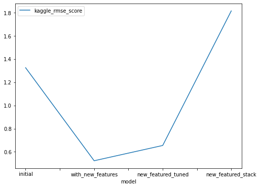

```python
# Taking the top kaggle model score
fig = (
    pd.DataFrame(
        {
            "model": [
                "initial",
                "with_new_features",
                "new_featured_tuned",
                "new_featured_stack",
            ],
            "kaggle_rmse_score": [1.32582, 0.5231, 0.65488, 1.8161,],
        }
    )
    .plot(x="model", y="kaggle_rmse_score", figsize=(8, 6))
    .get_figure()
)
fig.savefig("model_kaggle_rmse_score.png")
```

# Summary

- we clearly see default tabular model built with new feature has better score rates compared to other models we tried.

## Next steps

- try different hyper parameter approach to see if we can beat default model